# A1.1 648241

**A1.1 Aprendizaje estadístico-automático**

1- A continuación importamos el archivo "*A1.1 Obesidad.csv*" utilizando la función *read_csv()*. Para comprobar que la información se importó con éxito, imprimimos los primeros 10 ejemplos con la función *head(10)* y con esto confirmamos que se importó correctamente los datos.

```python
import pandas as pd
datos = pd.read_csv("A1.1 Obesidad.csv")
print(datos.head(10))
```

```
     Sexo  Edad  Estatura  Peso FamiliarConSobrepeso ComeMuchasCalorias  \
0  Female  21.0      1.62  64.0                  yes                 no
1  Female  21.0      1.52  56.0                  yes                 no
2    Male  23.0      1.80  77.0                  yes                 no
3    Male  27.0      1.80  87.0                   no                 no
4    Male  22.0      1.78  89.8                   no                 no
5    Male  29.0      1.62  53.0                   no                yes
6  Female  23.0      1.50  55.0                  yes                yes
7    Male  22.0      1.64  53.0                   no                 no
8    Male  24.0      1.78  64.0                  yes                yes
9    Male  22.0      1.72  68.0                  yes                yes

   ComeVegetales Fumador  ConsumoDeAgua      NivelDeObesidad
0            2.0      no            2.0        Normal_Weight
1            3.0     yes            3.0        Normal_Weight
2            2.0      no            2.0        Normal_Weight
3            3.0      no            2.0   Overweight_Level_I
4            2.0      no            2.0  Overweight_Level_II
5            2.0      no            2.0        Normal_Weight
6            3.0      no            2.0        Normal_Weight
7            2.0      no            2.0        Normal_Weight
8            3.0      no            2.0        Normal_Weight
9            2.0      no            2.0        Normal_Weight
```

2- Otra variable que me hubiera gustado medir si hubiera formado parte del equipo de investigación:

**Porcentaje de masa corporal** y esta es una variable *cuantitativa*.

Investigando un poco sobre esta variable a medir se tiene en cuenta que en los hombres un porcentaje normal es de 10% a 20%, con sobrepeso es de 20% a 25% y se considera obesidad si es mayor a 25%. En las mujeres los porcentajes cambian ya que un porcentaje normal es de 20% a 30%, con sobrepeso es de 30% a 35% y se considera obesidad si es mayor a 35%.

3- Si tuviera que hacer un estudio de inferencia, la variable que yo definiría como salida o respuesta sería *NivelDeObesidad* ya que siento que es la variable en la cual todas las demás influyen. La variable es *cualitativa*.

Utilice la función *value_counts()* para calcular cuántas personas pertenencen en cada categoría de esta variable.

```python
print(datos.NivelDeObesidad.value_counts())
```

```
NivelDeObesidad
Obesity_Type_I         351
Obesity_Type_III       324
Obesity_Type_II        297
Overweight_Level_I     290
Overweight_Level_II    290
Normal_Weight          287
Insufficient_Weight    272
Name: count, dtype: int64
```

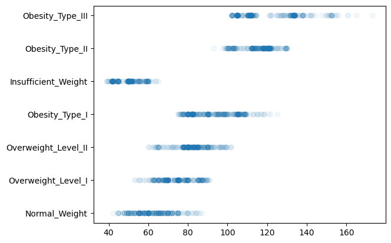

```python
import matplotlib.pyplot as plt
y= datos.NivelDeObesidad[datos.Sexo == "Male"]
x= datos.Peso[datos.Sexo == "Male"]

plt.scatter(x = datos.Peso , y = datos.NivelDeObesidad , alpha = 0.05)
plt.show()
```

**Referencias**

- Dávila-Batista, V., Gómez-Ambrosi, J., Fernández-Villa, T., Molina, A. J., Frühbeck, G., & Martín, V. (2016). Colour scale percent body fat by CUN-BAE adiposity estimator. Atencion primaria, 48(6), 422–423. https://doi.org/10.1016/j.aprim.2015.09.003

*Doy mi palabra que he realizado esta actividad con integridad académica* *Carlos Garza García - 648241*